# Phishing Email Detection: Random Forest vs. Gradient Boosting on Imbalanced Data

Luke Wamalwa

2025-04-20 (revised 2026-10-27)

## Question

Can eight simple count features (word counts, links, domains, email addresses, spelling errors, urgent keywords) separate phishing from legitimate email, and does rebalancing the training data (down-sampling, up-sampling, ROSE) help a Random Forest or GBM do it?

Only about 1.3% of emails are phishing, so **accuracy is not used**. A model that never flags anything is 98.7% “accurate”. The headline metric is **PR-AUC** (average precision), with precision, recall and F1 at a chosen threshold. ROC-AUC and balanced accuracy are reported for reference.

## Protocol (what touches what)

1. Stratified split of the full dataset: 60% train / 20% validation / 20% test.
2. Resampling (down / up / ROSE) is applied **to the training set only**. Validation and test keep the real class balance.
3. Every model is fit on (a version of) the training set and scored on validation.
4. The champion is chosen **on validation** by PR-AUC, and its decision threshold is chosen **on validation** (the F1-maximising threshold).
5. The test set is used **once**, for the champion at that fixed threshold. The model is *not* refit on train + validation, because refitting changes the probability scale and would invalidate the validation-tuned threshold.

```r
library(caret)         # createDataPartition, downSample, upSample
library(ROSE)          # ovun.sample
library(randomForest)  # Random Forest
library(gbm)           # Gradient boosting
library(pROC)          # ROC-AUC
library(ggplot2)

set.seed(42)
dir.create("figures", showWarnings = FALSE)
```

## 1) Load data

Data: [Email Phishing Dataset (Kaggle, ethancratchley)](https://www.kaggle.com/datasets/ethancratchley/email-phishing-dataset/data), committed here as `email_phishing_data.csv`. All rows are used (no subsampling).

```r
df <- read.csv("email_phishing_data.csv")
df$label <- factor(df$label, levels = c(0, 1), labels = c("ham", "phish"))
predictors <- setdiff(names(df), "label")

dim(df)
```

```
## [1] 524846      9
```

```r
table(df$label)
```

```
##
##    ham  phish
## 517897   6949
```

```r
round(prop.table(table(df$label)), 4)
```

```
##
##    ham  phish
## 0.9868 0.0132
```

A data-quality note: many rows are exact duplicates of each other on all eight features. Short emails naturally collide (e.g. “5 words, 5 unique, 1 stopword, nothing else”), and some templated messages repeat thousands of times.

```r
dup_share <- mean(duplicated(df[, predictors]))
cat(sprintf("Rows whose feature vector already appeared earlier: %.1f%%\n", 100 * dup_share))
```

```
## Rows whose feature vector already appeared earlier: 61.1%
```

Because of this, a random split puts identical feature vectors in both train and test. Section 7 checks how much that flatters the test score.

## 2) Split data

```r
train_idx  <- createDataPartition(df$label, p = 0.60, list = FALSE)
train_all  <- df[ train_idx, ]
rest       <- df[-train_idx, ]

val_idx    <- createDataPartition(rest$label, p = 0.50, list = FALSE)
validation <- rest[ val_idx, ]
test       <- rest[-val_idx, ]

sapply(list(train = train_all, validation = validation, test = test),
       function(d) c(n = nrow(d), phish = sum(d$label == "phish"),
                     phish_rate = round(mean(d$label == "phish"), 4)))
```

```
##                  train  validation        test
## n          314909.0000 104969.0000 104968.0000
## phish        4170.0000   1390.0000   1389.0000
## phish_rate      0.0132      0.0132      0.0132
```

## 3) Balance the TRAINING set four ways

```r
train_down <- downSample(x = train_all[, predictors], y = train_all$label, yname = "label")
train_up   <- upSample(  x = train_all[, predictors], y = train_all$label, yname = "label")
N_target   <- max(table(train_all$label)) * 2
train_rose <- ovun.sample(label ~ ., data = train_all, method = "both",
                          N = N_target, seed = 42)$data

train_sets <- list(Original = train_all, Down = train_down,
                   Up = train_up, ROSE = train_rose)
sapply(train_sets, function(d) table(d$label))
```

```
##       Original Down     Up   ROSE
## ham     310739 4170 310739 310675
## phish     4170 4170 310739 310803
```

## 4) Helpers: metrics and threshold search

```r
# Average precision (PR-AUC), tie-aware: one PR point per distinct score.
pr_curve <- function(probs, truth) {
  y   <- as.integer(truth == "phish")
  ord <- order(probs, decreasing = TRUE)
  p   <- probs[ord]; y <- y[ord]
  last <- c(p[-1] != p[-length(p)], TRUE)       # last row of each tied block
  tp <- cumsum(y)[last]; fp <- cumsum(1 - y)[last]
  data.frame(Recall = tp / sum(y), Precision = tp / (tp + fp))
}

pr_auc <- function(probs, truth) {
  cv <- pr_curve(probs, truth)
  sum(diff(c(0, cv$Recall)) * cv$Precision)
}

compute_metrics <- function(probs, truth, thr) {
  pred <- probs > thr
  pos  <- truth == "phish"
  tp <- sum(pred & pos); fp <- sum(pred & !pos)
  fn <- sum(!pred & pos); tn <- sum(!pred & !pos)
  prec <- if (tp + fp == 0) NA else tp / (tp + fp)
  rec  <- tp / (tp + fn)
  spec <- tn / (tn + fp)
  f1   <- if (is.na(prec) || prec + rec == 0) NA else 2 * prec * rec / (prec + rec)
  c(Threshold = thr, Precision = prec, Recall = rec, F1 = f1,
    BalancedAccuracy = (rec + spec) / 2, TP = tp, FP = fp, FN = fn, TN = tn)
}

scan_thresholds <- function(probs, truth, ths = seq(0.01, 0.99, by = 0.01)) {
  as.data.frame(t(sapply(ths, function(t) compute_metrics(probs, truth, t))))
}

best_f1_threshold <- function(probs, truth) {
  m <- scan_thresholds(probs, truth)
  m[which.max(m$F1), , drop = FALSE]
}
```

## 5) Train both models on each training set, evaluate on validation

Random Forest: 100 trees, default settings. GBM: 100 trees, depth 3, learning rate 0.1.

```r
fit_rf <- function(tr) {
  tr$label <- factor(tr$label, levels = c("ham", "phish"))
  randomForest(label ~ ., data = tr[, c(predictors, "label")], ntree = 100)
}
fit_gbm <- function(tr) {
  tr$label_n <- ifelse(tr$label == "phish", 1, 0)
  gbm(label_n ~ ., data = tr[, c(predictors, "label_n")],
      distribution = "bernoulli", n.trees = 100, interaction.depth = 3,
      shrinkage = 0.1, bag.fraction = 0.8, n.minobsinnode = 5, verbose = FALSE)
}
predict_prob <- function(mod, newdata) {
  if (inherits(mod, "randomForest")) predict(mod, newdata, type = "prob")[, "phish"]
  else predict(mod, newdata = newdata[, predictors], n.trees = 100, type = "response")
}

models <- list(); val_probs <- list(); results <- NULL
for (balance in names(train_sets)) {
  for (model_name in c("RandomForest", "GBM")) {
    key <- paste(balance, model_name, sep = " + ")
    set.seed(42)
    mod <- if (model_name == "RandomForest") fit_rf(train_sets[[balance]]) else fit_gbm(train_sets[[balance]])
    p   <- predict_prob(mod, validation)
    best <- best_f1_threshold(p, validation$label)
    models[[key]]    <- mod
    val_probs[[key]] <- p
    results <- rbind(results, data.frame(
      Sampling = balance, Model = model_name,
      PR_AUC   = pr_auc(p, validation$label),
      ROC_AUC  = as.numeric(auc(roc(validation$label, p, levels = c("ham", "phish"),
                                    direction = "<", quiet = TRUE))),
      Threshold = best$Threshold, Precision = best$Precision,
      Recall = best$Recall, F1 = best$F1,
      BalancedAccuracy = best$BalancedAccuracy, row.names = NULL))
  }
}
```

## 6) Validation results and champion selection

No-skill PR-AUC equals the phishing rate in validation: 0.0132.

```r
results <- results[order(-results$PR_AUC), ]
knitr::kable(results, digits = 3, row.names = FALSE,
             caption = "Validation set. Threshold = F1-maximising threshold on validation.")
```

Validation set. Threshold = F1-maximising threshold on validation.

| Sampling | Model | PR_AUC | ROC_AUC | Threshold | Precision | Recall | F1 | BalancedAccuracy |
| --- | --- | --- | --- | --- | --- | --- | --- | --- |
| Original | RandomForest | 0.320 | 0.782 | 0.08 | 0.495 | 0.317 | 0.386 | 0.656 |
| ROSE | RandomForest | 0.228 | 0.843 | 0.90 | 0.362 | 0.240 | 0.288 | 0.617 |
| Up | RandomForest | 0.216 | 0.840 | 0.90 | 0.369 | 0.231 | 0.284 | 0.613 |
| Down | RandomForest | 0.148 | 0.855 | 0.92 | 0.202 | 0.270 | 0.231 | 0.628 |
| Original | GBM | 0.117 | 0.785 | 0.07 | 0.216 | 0.139 | 0.169 | 0.566 |
| Down | GBM | 0.089 | 0.799 | 0.76 | 0.141 | 0.181 | 0.158 | 0.583 |
| Up | GBM | 0.087 | 0.800 | 0.75 | 0.129 | 0.178 | 0.150 | 0.581 |
| ROSE | GBM | 0.086 | 0.801 | 0.74 | 0.124 | 0.203 | 0.154 | 0.592 |

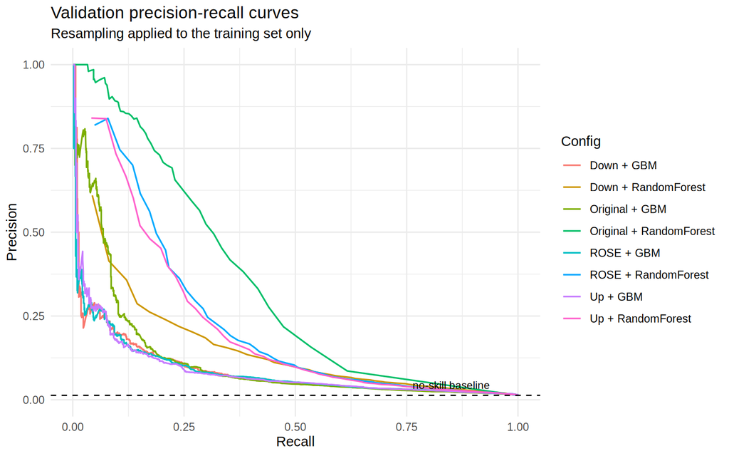

Precision-recall curves on the validation set.

```r
curves <- do.call(rbind, lapply(names(val_probs), function(k)
  cbind(pr_curve(val_probs[[k]], validation$label), Config = k)))
base_rate <- mean(validation$label == "phish")
p_pr <- ggplot(curves, aes(Recall, Precision, colour = Config)) +
  geom_line(linewidth = 0.6) +
  geom_hline(yintercept = base_rate, linetype = "dashed") +
  annotate("text", x = 0.85, y = base_rate + 0.03, label = "no-skill baseline", size = 3) +
  coord_cartesian(ylim = c(0, 1)) +
  labs(title = "Validation precision-recall curves",
       subtitle = "Resampling applied to the training set only") +
  theme_minimal()
ggsave("figures/pr_curves_validation.png", p_pr, width = 8, height = 5, dpi = 120)
p_pr
```

```r
champ_row <- results[1, ]
champ_key <- paste(champ_row$Sampling, champ_row$Model, sep = " + ")
champ_thr <- champ_row$Threshold
champ_mod <- models[[champ_key]]
cat("Champion (highest validation PR-AUC):", champ_key,
    "\nF1-optimal threshold chosen on validation:", champ_thr, "\n")
```

```
## Champion (highest validation PR-AUC): Original + RandomForest
## F1-optimal threshold chosen on validation: 0.08
```

A second, high-recall operating point for the same model is also fixed on validation: the highest threshold that still catches at least 50% of phishing.

```r
val_scan <- scan_thresholds(val_probs[[champ_key]], validation$label)
hr_thr   <- max(val_scan$Threshold[val_scan$Recall >= 0.5])
cat("High-recall threshold chosen on validation:", hr_thr, "\n")
```

```
## High-recall threshold chosen on validation: 0.01
```

## 7) Final evaluation on the TEST set (used once)

```r
test_prob <- predict_prob(champ_mod, test)
test_metrics <- rbind(
  `F1-optimal threshold`  = compute_metrics(test_prob, test$label, champ_thr),
  `High-recall threshold` = compute_metrics(test_prob, test$label, hr_thr))
test_pr_auc  <- pr_auc(test_prob, test$label)
test_roc_auc <- as.numeric(auc(roc(test$label, test_prob, levels = c("ham", "phish"),
                                   direction = "<", quiet = TRUE)))
cat(sprintf("Test PR-AUC: %.3f (no-skill %.4f)   Test ROC-AUC: %.3f\n",
            test_pr_auc, mean(test$label == "phish"), test_roc_auc))
```

```
## Test PR-AUC: 0.322 (no-skill 0.0132)   Test ROC-AUC: 0.797
```

```r
knitr::kable(test_metrics, digits = 3,
             caption = paste("Test set,", champ_key))
```

Test set, Original + RandomForest

|  | Threshold | Precision | Recall | F1 | BalancedAccuracy | TP | FP | FN | TN |
| --- | --- | --- | --- | --- | --- | --- | --- | --- | --- |
| F1-optimal threshold | 0.08 | 0.508 | 0.300 | 0.377 | 0.648 | 417 | 404 | 972 | 103175 |
| High-recall threshold | 0.01 | 0.157 | 0.544 | 0.243 | 0.752 | 756 | 4074 | 633 | 99505 |

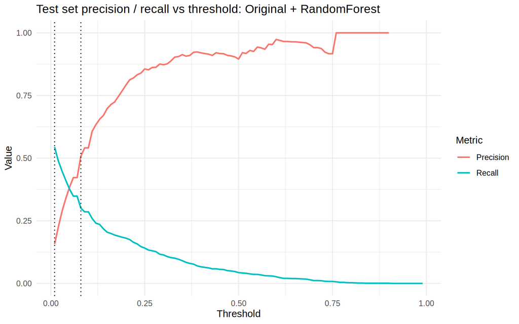

Precision and recall on the test set as the threshold moves. Dotted lines mark the two thresholds fixed on validation.

```r
test_scan <- scan_thresholds(test_prob, test$label)
long <- rbind(data.frame(Threshold = test_scan$Threshold, Metric = "Precision", Value = test_scan$Precision),
              data.frame(Threshold = test_scan$Threshold, Metric = "Recall",    Value = test_scan$Recall))
p_thr <- ggplot(long, aes(Threshold, Value, colour = Metric)) +
  geom_line(linewidth = 0.8, na.rm = TRUE) +
  geom_vline(xintercept = c(champ_thr, hr_thr), linetype = "dotted") +
  labs(title = paste("Test set precision / recall vs threshold:", champ_key)) +
  theme_minimal()
ggsave("figures/test_threshold_tradeoff.png", p_thr, width = 8, height = 5, dpi = 120)
p_thr
```

### Robustness: test emails whose feature vector never appears in training

This is a diagnostic, not a model-selection step: nothing is tuned on it.

```r
key_of <- function(d) do.call(paste, d[, predictors])
unseen <- !(key_of(test) %in% key_of(train_all))
cat(sprintf("Test rows with a feature vector unseen in training: %d of %d (%.1f%%), phishing rate %.4f\n",
            sum(unseen), nrow(test), 100 * mean(unseen), mean(test$label[unseen] == "phish")))
```

```
## Test rows with a feature vector unseen in training: 30395 of 104968 (29.0%), phishing rate 0.0354
```

```r
cat(sprintf("PR-AUC on unseen rows: %.3f (no-skill %.4f)\nPR-AUC on rows also seen in training: %.3f (no-skill %.4f)\n",
            pr_auc(test_prob[unseen], test$label[unseen]),  mean(test$label[unseen] == "phish"),
            pr_auc(test_prob[!unseen], test$label[!unseen]), mean(test$label[!unseen] == "phish")))
```

```
## PR-AUC on unseen rows: 0.299 (no-skill 0.0354)
## PR-AUC on rows also seen in training: 0.429 (no-skill 0.0042)
```

```r
knitr::kable(rbind(
  `Unseen, F1 threshold` = compute_metrics(test_prob[unseen],  test$label[unseen],  champ_thr),
  `Seen, F1 threshold`   = compute_metrics(test_prob[!unseen], test$label[!unseen], champ_thr)),
  digits = 3)
```

|  | Threshold | Precision | Recall | F1 | BalancedAccuracy | TP | FP | FN | TN |
| --- | --- | --- | --- | --- | --- | --- | --- | --- | --- |
| Unseen, F1 threshold | 0.08 | 0.462 | 0.276 | 0.345 | 0.632 | 297 | 346 | 780 | 28972 |
| Seen, F1 threshold | 0.08 | 0.674 | 0.385 | 0.490 | 0.692 | 120 | 58 | 192 | 74203 |

## Conclusions

- The best model is the plain Random Forest on the **original, un-resampled** training data (validation PR-AUC 0.32, test PR-AUC 0.322 against a no-skill 0.0132).
- Resampling raised ROC-AUC slightly but **lowered PR-AUC** for both model families: it improves ranking over the whole range but hurts the high-precision end, which is what matters when ~99% of email is legitimate.
- At the validation-chosen threshold (0.08) the champion catches 30% of test phishing with 51% precision. Pushing recall above 50% costs precision sharply (16% at threshold 0.01).
- Part of the score comes from feature vectors that also occur in training; on unseen vectors the model still beats the no-skill baseline clearly, but precision and recall are lower.
- These eight count features carry real but limited signal. Message text, sender/header information and URL reputation would be needed for a production-grade filter.